## Jacaranda Python 入门课程 - 第四节：函数的书写以及类对象的介绍

```
                                            - By Andy
```

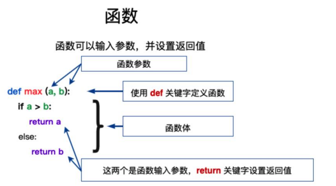

# 创建函数def

1. 操作性函数
2. 输出型函数

**操作性函数**

- return None
- 对原有的输入进行改变

```python
ori = []
def change_ori(ori):
    ori.append('i am changed')

print(change_ori(ori))
print(ori)
```

```
None
['i am changed']
```

**输出性函数**

- return required output
- 对原有输入不改变

```python
ori = []
def keep_ori(ori):
    ori = ori.copy()
    ori.append('i am changed')
    return ori

print(keep_ori(ori))
print(ori)
print('\n')
```

```
['i am changed']
[]
```

函数基础语法

```python
def p(item):
    print(item,'\n')
p('函数的调用')
```

```
函数的调用
```

# 参数

1. 必须参数(must)  
   Def function(name):  
   调用函数的时候必须输入的参数, name
2. 默认参数(dafult)  
   Def function(name=Jacaranda):  
   调用函数的时候可以选择不输入的参数，不输入时为默认值

```python
def canshu1(must,default = '默认'):
    print('这是必须参数',must)
    print('这是默认参数',default,'\n')

canshu1('a',default='b')
canshu1('a')
```

```
这是必须参数 a
这是默认参数 b

这是必须参数 a
这是默认参数 默认
```

3. 不定长参数  
   调用函数的时候可以输入无限个数据的参数

Def function(*name):

- *name的数据会以tuple的形式导入
  - 如1,2导入后为（1,2）

```python
def canshu2(must,*long):
    print('这是必须参数',must)
    print('这是不定长参数的tuple导入形式',long)

canshu2('a','b','c')
```

```
这是必须参数 a
这是不定长参数的tuple导入形式 ('b', 'c')
```

```python
def canshu2(must, must_1, *long):
    print('这是必须参数',must,must_1)
    print('这是不定长参数的tuple导入形式',long)

canshu2('a','b','c')
```

```
这是必须参数 a b
这是不定长参数的tuple导入形式 ('c',)
```

Def function(**name):

- *name的数据会以dictionary的形式导入
  - 如a=1,b=2导入后为 {a:1, b:2}

```python
def canshu3(must,**long):
    print('这是必须参数',must)
    print('这是这是不定长参数的字典导入形式',long)

canshu3('a',b='b1',c='c2')
```

```
这是必须参数 a
这是这是不定长参数的字典导入形式 {'b': 'b1', 'c': 'c2'}
```

**全局变量 (global variable)**

- 有效范围为整个程序空间
- 在程序的任何一个地方都可以访问这个变量，不管是在函数内部还是函数外部

**局部变量 (local variable)**

- 函数内部定义的变量
- 出了函数就不能使用了

```python
all = '我是全局变量'
def get_all():
    #global all
    all = '我是局部变量'
    print(all)
get_all()
print(all)
```

```
我是局部变量
我是全局变量
```

**Lambda**

- Lambda 是一个匿名函数，即只包括函数的 process, 但是不包括函数的名字
- 是一种简单的、在同一行中定义函数的方法
- lambda <参数>: <return value>

```python
def my_key(item):
    return item[::-1]

my_list = ['cz', 'bz', 'az']
print(sorted(my_list, key=my_key))
print(sorted(my_list, key=lambda item: item[::-1]))
```

```
['az', 'bz', 'cz']
['az', 'bz', 'cz']
```

# 类 Class

1. 用来描述具有相同属性和方法的对象的集合，它定义了集合中每一个对象所共有的

属性和方法 2. 当我们需要对一类事情进行统一化重复性操作的时候，为了减少工作量，我们会选 择创建一个 class 来将他们归类，从而避免对这一类对象的共有属性进行多次编辑， 从而更注重于他们的不同

**类的创建**

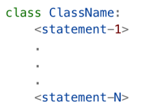

Class（家长）

> Attribute属性（子孙）-遗传家长特征，如长相，身高，体型

> > Methods方法 （生活技能） -继承生活技能，如说话，行走，跑步

```python
class GC: #Game Character首字母大写
    level = 1
    exp = 0

player1 = GC()
player2 = GC()

print(player1.level)
print(player2.exp)
```

```
1
0
```

从class产生的个体也可以拥有自己的专属属性

```python
player1.name = "john"
player2.name = "doe"

print(player1.name)
print(player2.name)
```

```
john
doe
```

**Initialize 初始化**

```python
class GC:
    level = 1
    exp = 0

    def __init__(self, name, age):
        self.name = name
        self.age = age

player1 = GC("john", 18)
player2= GC("doe", 22)

print(player1.name)
print(player2.age)
```

```
john
22
```

**Methods 方法**  
某个物件可用来执行特定任务的函式

```python
class GC:
    level = 1
    exp = 0

    def __init__(self, name, age):
        self.name = name
        self.age = age

    def attack(self):
        print(f"{self.name} attacked!")

    def watch(self):
        print(f"{self.name} stares at you O.o")

player1 = GC("john", 18)
player2= GC("doe", 22)

player1.attack()
player2.watch()
```

```
john attacked!
doe stares at you O.o
```

**私有方法**  
只能内部调用

```python
class GC:
    level = 1
    exp = 0

    def __init__(self, name, age):
        self.name = name
        self.age = age

    def __speak(self): #类的私有方法
        print('AHAHAHAHAHAHAHAHAHAHAHA')

    def yell(self): #调用私有方法
        self.__speak()

player1 = GC("john", 18)
player2= GC("doe", 22)


player1.yell()
```

```
AHAHAHAHAHAHAHAHAHAHAHA
```

**类对象的继承**  
一个新的类可以继承一个父类的所有方法和属性

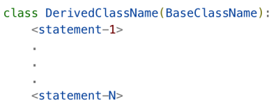

```python
class GC:
    level = 1
    exp = 0

    def __init__(self, name, age):
        self.name = name
        self.age = age

    def attack(self):
        print(f"{self.name} attacked!")

    def watch(self):
        print(f"{self.name} stares at you O.o")

class hop(GC):
    def jump(self):
        print(f"{self.name} jumpped!!!")

player1 = hop("john doe", 99)
player1.attack()
player1.jump()
```

```
john doe attacked!
john doe jumpped!!!
```